# Final_Project

## Clustering (k-means)

###### PCA reduces the dimensionality of the data, which can make clustering more efficient and can help improve the performance of clustering algorithms like K-means.

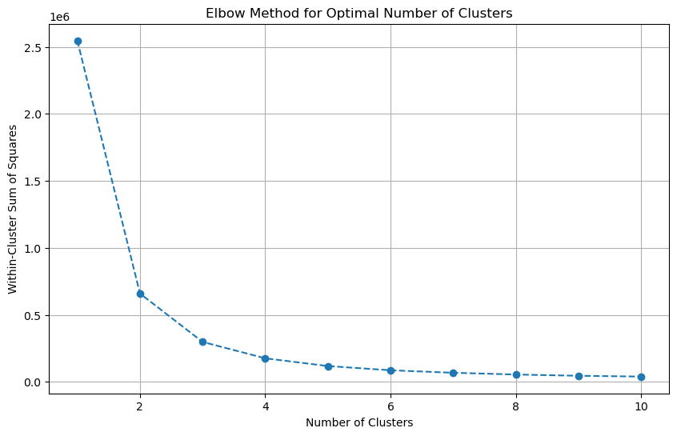

```python
wcss = []
for i in range(1, 11):
    kmeans = KMeans(n_clusters=i, random_state=42)
    kmeans.fit(df_pca)
    wcss.append(kmeans.inertia_)

plt.figure(figsize=(10, 6))
plt.plot(range(1, 11), wcss, marker='o', linestyle='--')
plt.xlabel('Number of Clusters')
plt.ylabel('Within-Cluster Sum of Squares')
plt.title('Elbow Method for Optimal Number of Clusters')
plt.grid(True)
plt.show()
```

### K-Means clustering with 3 clusters

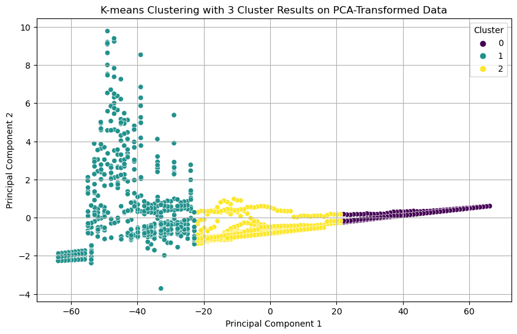

```python
kmeans = KMeans(n_clusters=3, random_state=42)
kmeans.fit(df_pca)

df_pca_with_labels_k3 = pd.DataFrame(df_pca, columns=[f'PC{i+1}' for i in range(9)])
df_pca_with_labels_k3['Cluster'] = kmeans.labels_

plt.figure(figsize=(10, 6))
sns.scatterplot(x='PC1', y='PC2', hue='Cluster', data=df_pca_with_labels_k3, palette='viridis')
plt.title('K-means Clustering with 3 Cluster Results on PCA-Transformed Data')
plt.xlabel('Principal Component 1')
plt.ylabel('Principal Component 2')
plt.legend(title='Cluster')
plt.grid(True)
plt.show()
```

```python
silhouette_score_k3 = silhouette_score(df_pca, kmeans.labels_)
print(f'Silhouette Score for 3 clusters: {silhouette_score_k3}')
```

```
Silhouette Score for 3 clusters: 0.5747992885207062
```

## PCA with 4 number of clusters

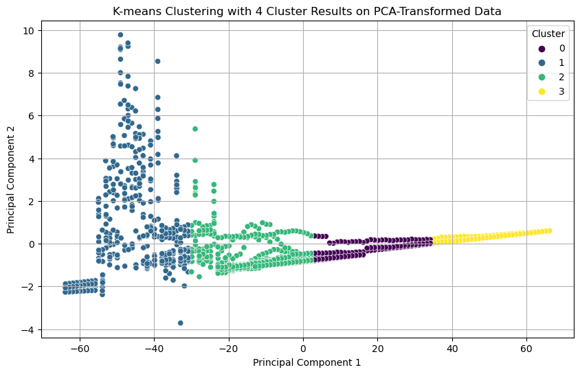

```python
kmeans = KMeans(n_clusters=4, random_state=42)
kmeans.fit(df_pca)

df_pca_with_labels_k4 = pd.DataFrame(df_pca, columns=[f'PC{i+1}' for i in range(9)])
df_pca_with_labels_k4['Cluster'] = kmeans.labels_

plt.figure(figsize=(10, 6))
sns.scatterplot(x='PC1', y='PC2', hue='Cluster', data=df_pca_with_labels_k4, palette='viridis')
plt.title('K-means Clustering with 4 Cluster Results on PCA-Transformed Data')
plt.xlabel('Principal Component 1')
plt.ylabel('Principal Component 2')
plt.legend(title='Cluster')
plt.grid(True)
plt.show()
```

```python
silhouette_score_k4 = silhouette_score(df_pca, kmeans.labels_)
print(f'Silhouette Score for 4 clusters: {silhouette_score_k4}')
```

```
Silhouette Score for 4 clusters: 0.5474095757711896
```

```python
cluster_means = df_pca_with_labels_k4.groupby('Cluster').mean()
print(cluster_means)
```

```
               PC1       PC2       PC3       PC4       PC5       PC6  \
Cluster
0        18.356696 -0.322971  0.098578 -0.040155 -0.016502 -0.017826
1       -47.387413  0.502353  0.243983 -0.307906  0.104539 -0.085583
2       -13.869780 -0.501149 -0.488392  0.601000 -0.160787  0.184869
3        50.651124  0.315597  0.161329 -0.273635  0.076007 -0.088958

              PC7       PC8       PC9
Cluster
0       -0.278942  0.074812  0.137133
1        0.262098  0.019741 -0.344334
2       -0.271551 -0.069427  0.464406
3        0.290007 -0.022814 -0.263509
```

## Hierarchical Clustering

#### Hierarchical clustering is another effective clustering method, which can provide a hierarchical decomposition of the data.

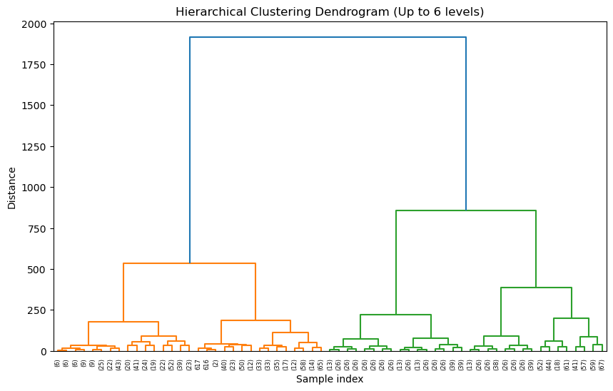

```python
Z = linkage(df_pca, method='ward')

plt.figure(figsize=(10, 6))
dendrogram(Z, truncate_mode='level', p=5)
plt.title('Hierarchical Clustering Dendrogram (Up to 6 levels)')
plt.xlabel('Sample index')
plt.ylabel('Distance')
plt.show()
```

```
Best threshold for hierarchical clustering: 95
Highest Silhouette Score: 0.44617323020249855
```

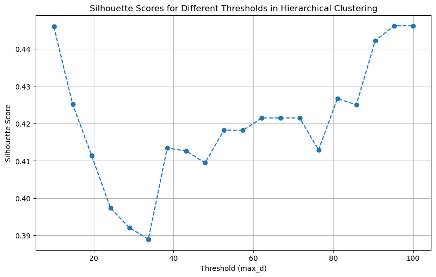

```python
import numpy as np
from sklearn.metrics import silhouette_score
from scipy.cluster.hierarchy import fcluster

Z = linkage(df_pca, method='ward')

thresholds = np.linspace(10, 100, 20)

best_threshold = None
best_silhouette_score = -1
silhouette_scores = []

for thresh in thresholds:
    clusters = fcluster(Z, thresh, criterion='distance')
    if len(set(clusters)) > 1:
        score = silhouette_score(df_pca, clusters)
        silhouette_scores.append(score)
        if score > best_silhouette_score:
            best_silhouette_score = score
            best_threshold = thresh
    else:
        silhouette_scores.append(-1)
best_threshold_rounded = round(best_threshold)
print(f'Best threshold for hierarchical clustering: {best_threshold_rounded}')
print(f'Highest Silhouette Score: {best_silhouette_score}')

plt.figure(figsize=(10, 6))
plt.plot(thresholds, silhouette_scores, marker='o', linestyle='--')
plt.xlabel('Threshold (max_d)')
plt.ylabel('Silhouette Score')
plt.title('Silhouette Scores for Different Thresholds in Hierarchical Clustering')
plt.grid(True)
plt.show()
```

```python
import pandas as pd
from scipy.cluster.hierarchy import dendrogram, linkage, fcluster

max_d = best_threshold_rounded
clusters = fcluster(Z, max_d, criterion='distance')

df_pca_with_labels = pd.DataFrame(df_pca, columns=[f'PC{i+1}' for i in range(df_pca.shape[1])])
df_pca_with_labels['Cluster'] = clusters

df_completed_with_clusters = df_completed.copy()
df_completed_with_clusters['Cluster'] = clusters

def analyze_cluster(cluster_number):
    df_cluster = df_completed_with_clusters[df_completed_with_clusters['Cluster'] == cluster_number]
    summary = df_cluster.describe()
    return summary

unique_clusters = df_completed_with_clusters['Cluster'].unique()

cluster_summaries = {}

for cluster_number in unique_clusters:
    cluster_summaries[cluster_number] = analyze_cluster(cluster_number)

for cluster_number in range(1, min(6, len(unique_clusters) + 1)):
    print(f"\nSummary Statistics for Cluster {cluster_number}:")
    print(cluster_summaries[cluster_number])
```

```
Summary Statistics for Cluster 1:
              Year  Corruption_Index  Poverty_Share  Oil_Production  \
count   126.000000      1.260000e+02     126.000000    1.260000e+02
mean   2026.000000      1.000000e+00       9.805476    1.000000e+00
std       2.592296      6.687930e-16      14.659306    1.337586e-15
min    2022.000000      1.000000e+00       0.010000    1.000000e+00
25%    2024.000000      1.000000e+00       0.050000    1.000000e+00
50%    2026.000000      1.000000e+00       0.935000    1.000000e+00
75%    2028.000000      1.000000e+00      15.922500    1.000000e+00
max    2030.000000      1.000000e+00      44.420000    1.000000e+00

       Healthcare_Access_Index  Gender_Inequality_Index  GDP_per_Capita  \
count             1.260000e+02             1.260000e+02    1.260000e+02
mean              1.000000e+00             1.000000e+00    1.000000e+00
std               2.229310e-16             4.458620e-16    6.687930e-16
min               1.000000e+00             1.000000e+00    1.000000e+00
25%               1.000000e+00             1.000000e+00    1.000000e+00
50%               1.000000e+00             1.000000e+00    1.000000e+00
75%               1.000000e+00             1.000000e+00    1.000000e+00
max               1.000000e+00             1.000000e+00    1.000000e+00

       Freedom_of_Expression_Index  Fair_Elections_Index  FDI_Outflows  \
count                 1.260000e+02          1.260000e+02  1.260000e+02
mean                  1.000000e+00          1.000000e+00  1.000000e+00
std                   1.114655e-15          1.337586e-15  1.560517e-15
min                   1.000000e+00          1.000000e+00  1.000000e+00
25%                   1.000000e+00          1.000000e+00  1.000000e+00
50%                   1.000000e+00          1.000000e+00  1.000000e+00
75%                   1.000000e+00          1.000000e+00  1.000000e+00
max                   1.000000e+00          1.000000e+00  1.000000e+00

        FDI_Inflows    Birth_Rate  Cardiovascular_Death_Rate  Cluster
count  1.260000e+02  1.260000e+02               1.260000e+02    126.0
mean   1.000000e+00  1.000000e+00               1.000000e+00      1.0
std    1.114655e-15  6.687930e-16               1.114655e-15      0.0
min    1.000000e+00  1.000000e+00               1.000000e+00      1.0
25%    1.000000e+00  1.000000e+00               1.000000e+00      1.0
50%    1.000000e+00  1.000000e+00               1.000000e+00      1.0
75%    1.000000e+00  1.000000e+00               1.000000e+00      1.0
max    1.000000e+00  1.000000e+00               1.000000e+00      1.0
```

[output cut: 149 more lines]

```
min                   1.000000e+00          1.000000e+00     -1.693586
25%                   1.000000e+00          1.000000e+00      0.000000
50%                   1.000000e+00          1.000000e+00      0.090306
75%                   1.000000e+00          1.000000e+00      0.901335
max                   1.000000e+00          1.000000e+00      4.088262

       FDI_Inflows  Birth_Rate  Cardiovascular_Death_Rate  Cluster
count   149.000000  149.000000                 149.000000    149.0
mean      1.522583   34.694711                 215.634161      5.0
std       3.984732    9.418876                 217.812521      0.0
min      -2.981628   15.093000                   1.000000      5.0
25%       0.015054   28.253000                   1.000000      5.0
50%       0.489360   36.377998                 251.070000      5.0
75%       1.343241   40.040001                 399.540000      5.0
max      37.261055   52.189999                 659.580000      5.0
```

### Cluster Analysis

```python
from sklearn.metrics import silhouette_score

hierarchical_silhouette_score = silhouette_score(df_pca, clusters)

print("Comparison of Clustering Methods:")
print(f"K-means - Silhouette Score: {silhouette_score_k4}")
print(f"Hierarchical - Silhouette Score: {hierarchical_silhouette_score}")
```

```
Comparison of Clustering Methods:
K-means - Silhouette Score: 0.5474095757711896
Hierarchical - Silhouette Score: 0.44617323020249855
```

# EDA

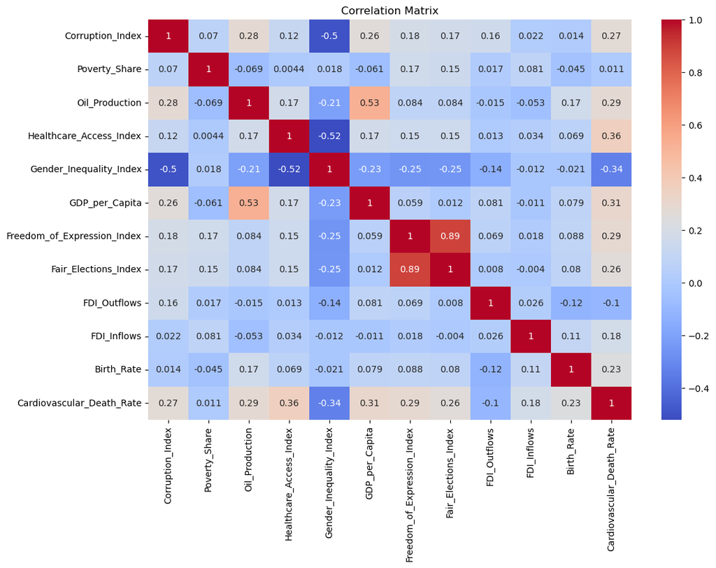

```python
# Correlation matrix for numeric columns
plt.figure(figsize=(12, 8))
sns.heatmap(df_completed[numeric_columns].corr(), annot=True, cmap='coolwarm')
plt.title('Correlation Matrix')
plt.show()
```

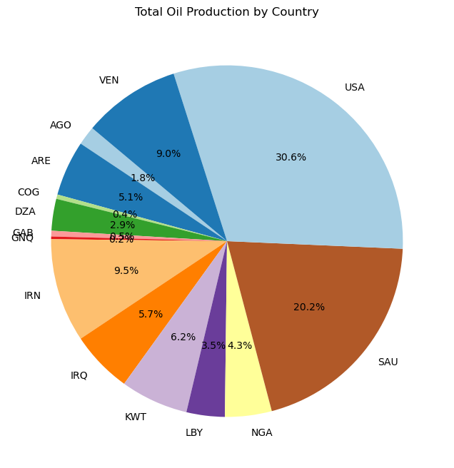

```python
import matplotlib.pyplot as plt

# Aggregate the total oil production for each country
total_oil_production = df_completed.groupby('Code')['Oil_Production'].sum()

# Create the pie chart
plt.figure(figsize=(10, 8))
plt.pie(total_oil_production, labels=total_oil_production.index, autopct='%1.1f%%', startangle=140, colors=plt.cm.Paired.colors)
plt.title('Total Oil Production by Country')
plt.show()
```

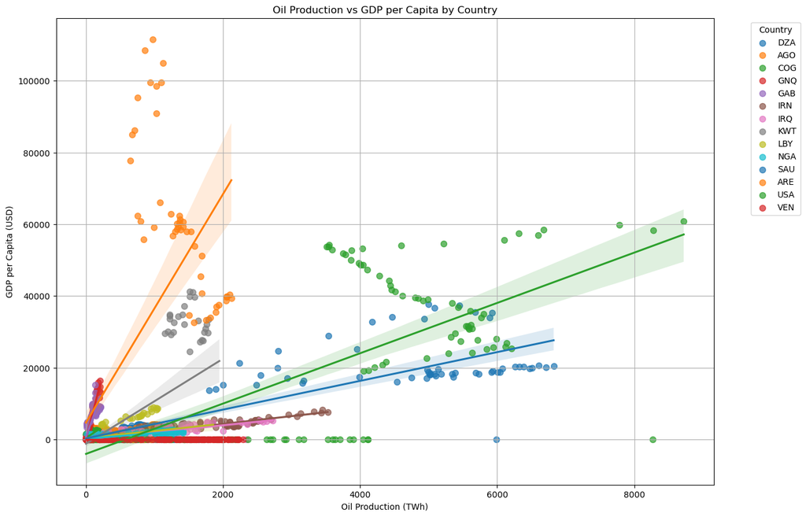

```python
import matplotlib.pyplot as plt
import seaborn as sns

# Set the size of the plot
plt.figure(figsize=(14, 10))

# Create a scatter plot for each country
for country_code in df_completed['Code'].unique():
    country_data = df_completed[df_completed['Code'] == country_code]
    sns.regplot(x='Oil_Production', y='GDP_per_Capita', data=country_data, label=country_code, scatter_kws={'s': 50, 'alpha': 0.7})

# Add labels and title
plt.xlabel('Oil Production (TWh)')
plt.ylabel('GDP per Capita (USD)')
plt.title('Oil Production vs GDP per Capita by Country')
plt.legend(title='Country', bbox_to_anchor=(1.05, 1), loc='upper left')
plt.grid(True)
plt.show()
```

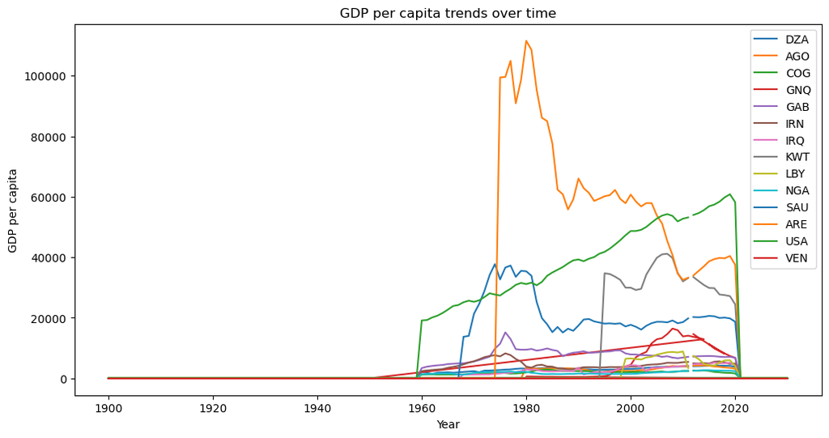

```python
# Line plot to see trends over time
plt.figure(figsize=(12, 6))
for country_code in df_completed['Code'].unique():
    country_data = df_completed[df_completed['Code'] == country_code]
    plt.plot(country_data['Year'], country_data['GDP_per_Capita'], label=country_code)
plt.xlabel('Year')
plt.ylabel('GDP per capita')
plt.title('GDP per capita trends over time')
plt.legend()
plt.show()
```

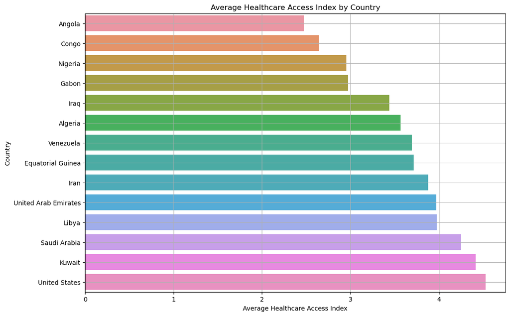

```python
import pandas as pd
import seaborn as sns
import matplotlib.pyplot as plt



# Bar Plot of Healthcare Access Index by Country
plt.figure(figsize=(12, 8))
country_mean = df_completed.groupby('Country')['Healthcare_Access_Index'].mean().sort_values()
sns.barplot(x=country_mean.values, y=country_mean.index)
plt.title('Average Healthcare Access Index by Country')
plt.xlabel('Average Healthcare Access Index')
plt.ylabel('Country')
plt.grid(True)
plt.show()
```

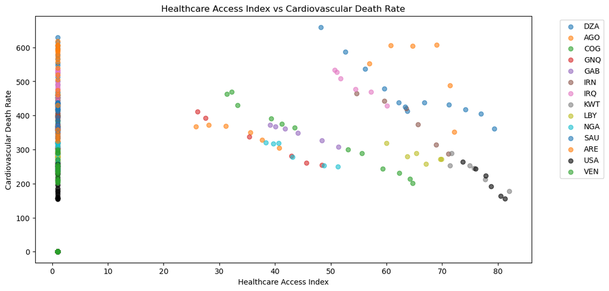

```python
import matplotlib.pyplot as plt

plt.figure(figsize=(12, 6))
for country_code in df_completed['Code'].unique():
    country_data = df_completed[df_completed['Code'] == country_code]
    if country_code == 'USA':  # Assuming 'USA' is the country code for the USA
        plt.scatter(country_data['Healthcare_Access_Index'], country_data['Cardiovascular_Death_Rate'], label=f'{country_code}', color='black', alpha=0.6)
    else:
        plt.scatter(country_data['Healthcare_Access_Index'], country_data['Cardiovascular_Death_Rate'], label=f'{country_code}', alpha=0.6)
plt.xlabel('Healthcare Access Index')
plt.ylabel('Cardiovascular Death Rate')
plt.title('Healthcare Access Index vs Cardiovascular Death Rate')
plt.legend(bbox_to_anchor=(1.05, 1), loc='upper left')
plt.show()
```

```python
# Calculate the averages for each country
avg_data = df_completed.groupby('Country').agg({
    'Cardiovascular_Death_Rate': 'mean',
    'Healthcare_Access_Index': 'mean'
}).reset_index()

# Print the dataframe
print("| Country      | Avg Cardiovascular Death Rate | Avg Healthcare Access Index |")
print("|--------------|-------------------------------|-----------------------------|")
for index, row in avg_data.iterrows():
    print(f"| {row['Country']}      | {row['Cardiovascular_Death_Rate']:.2f}                         | {row['Healthcare_Access_Index']:.2f}                        |")
```

```
| Country      | Avg Cardiovascular Death Rate | Avg Healthcare Access Index |
|--------------|-------------------------------|-----------------------------|
| Algeria      | 114.97                         | 3.57                        |
| Angola      | 79.52                         | 2.47                        |
| Congo      | 93.90                         | 2.64                        |
| Equatorial Guinea      | 116.19                         | 3.71                        |
| Gabon      | 79.17                         | 2.98                        |
| Iran      | 85.69                         | 3.88                        |
| Iraq      | 111.83                         | 3.44                        |
| Kuwait      | 52.81                         | 4.42                        |
| Libya      | 65.02                         | 3.98                        |
| Nigeria      | 65.76                         | 2.95                        |
| Saudi Arabia      | 94.04                         | 4.25                        |
| United Arab Emirates      | 119.23                         | 3.97                        |
| United States      | 46.42                         | 4.53                        |
| Venezuela      | 56.27                         | 3.70                        |
```

Healthcare Access and Cardiovascular Death Rate Relationship: The data suggests that countries with higher healthcare access indices tend to have lower average cardiovascular death rates. For instance, the USA has the highest healthcare access index (4.53) and the lowest cardiovascular death rate (46.42), indicating better healthcare access correlates with better health outcomes.

Variability Across Countries: There is significant variability in both the healthcare access index and cardiovascular death rates among the countries. Countries like GNQ (Equatorial Guinea) and ARE (United Arab Emirates) have high cardiovascular death rates (116.19 and 119.23, respectively) despite having moderately high healthcare access indices (3.71 and 3.97). This indicates that while healthcare access is a critical factor, other variables might be influencing health outcomes.

Middle Performers: Countries like KWT (Kuwait) and SAU (Saudi Arabia) have moderate cardiovascular death rates (52.81 and 94.04) and relatively higher healthcare access indices (4.42 and 4.25). This could suggest that these countries have somewhat effective healthcare systems that still have room for improvement.

```python
# Select the most useful features identified from the heatmap
selected_features = ['Healthcare_Access_Index',
    'Cardiovascular_Death_Rate',
    'GDP_per_Capita',
    'Oil_Production',
    'Fair_Elections_Index',
    'Freedom_of_Expression_Index',
    'Corruption_Index','Birth_Rate'
]

# Create a new DataFrame with only the selected features
s_df = d[selected_features]

# Display the first few rows of the selected DataFrame
s_df
```

|  | Healthcare_Access_Index | Cardiovascular_Death_Rate | GDP_per_Capita | Oil_Production | Fair_Elections_Index | Freedom_of_Expression_Index | Corruption_Index | Birth_Rate |
| --- | --- | --- | --- | --- | --- | --- | --- | --- |
| 0 | -0.213871 | 2.175069 | -0.080398 | 0.010962 | -0.199082 | -0.212996 | 3.666505 | 0.262318 |
| 1 | -0.213871 | 2.123572 | -0.078121 | -0.009788 | 6.120546 | 6.078142 | 3.901195 | 0.254670 |
| 2 | -0.213871 | 2.101149 | -0.072968 | 0.024285 | -0.199082 | -0.212996 | 3.901195 | 0.263471 |
| 3 | 4.938274 | 2.086201 | -0.068064 | 0.011073 | 4.856620 | 6.078142 | 3.901195 | 0.263523 |
| 4 | -0.213871 | 2.042432 | -0.064625 | 0.021260 | -0.199082 | -0.212996 | 3.666505 | 0.251002 |
| ... | ... | ... | ... | ... | ... | ... | ... | ... |
| 1779 | -0.213871 | -0.522264 | -0.379298 | -0.562694 | -0.199082 | -0.212996 | -0.205880 | 1.173719 |
| 1780 | -0.213871 | -0.522264 | -0.379298 | -0.562694 | -0.199082 | -0.212996 | -0.205880 | 1.179010 |
| 1781 | -0.213871 | -0.522264 | -0.379298 | -0.562694 | -0.199082 | -0.212996 | -0.205880 | 1.184511 |
| 1782 | -0.213871 | -0.522264 | -0.379298 | -0.562694 | -0.199082 | -0.212996 | -0.205880 | 1.189697 |
| 1783 | -0.213871 | -0.522264 | -0.379298 | -0.562694 | -0.199082 | -0.212996 | -0.205880 | 1.196822 |

1784 rows × 8 columns